# Week 9 Lab Assignment 1

Jonathan Bonaguro

March 27, 2020

## Assignments

Use the `mtcars` dataset (as a tibble) and to create the following plots.

1. Create a scatterplot using weight(wt) of the cars and miles per galon.
   1. Now change the color of the data points in the above scatterplot to any color of your choice.
   2. Now map the cylinder variable to the color aesthetic in the above scatterplot, by creating levels according to the number of cylinders.
   3. Now add a new layer to the above scatterplot that will fit a smoothed regression line to the above datapoints by using the geom_smooth() function.
   4. Now modify the above plot to show the smoothed regression line fit according to distinct levels of cylinders.
2. Create barplots to show the counts and proportion of cars according to
   1. distinct categories of transmission.
   2. distinct categories of transmission and the number of cylinders.
3. Using your knowledge on facets, create a scatter plot showing the relationship between weight of cars and miles per gallon and subset it according to the levels of cylinders.
   1. Now modify the above plot and subset the plot with your knowledge on facets, across levels of cylinders and gears.

#### Assignment 1

1. Create a scatterplot using weight(wt) of the cars and miles per galon.
   1. Now change the color of the data points in the above scatterplot to any color of your choice.
   2. Now map the cylinder variable to the color aesthetic in the above scatterplot, by creating levels according to the number of cylinders.
   3. Now add a new layer to the above scatterplot that will fit a smoothed regression line to the above datapoints by using the geom_smooth() function.
   4. Now modify the above plot to show the smoothed regression line fit according to distinct levels of cylinders.

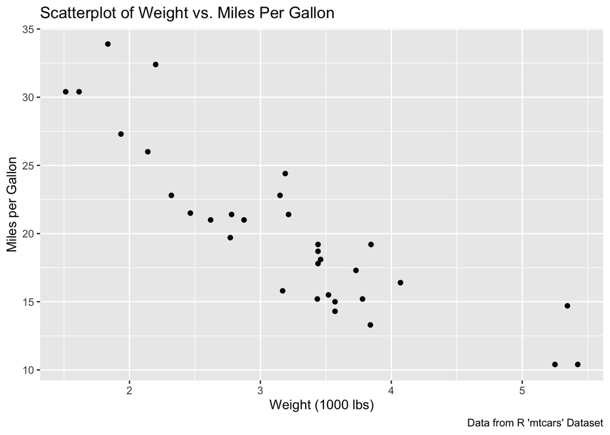

```r
ggplot(data = mtcars, mapping = aes(x = wt, y = mpg)) +
  geom_point() +
  labs(title = "Scatterplot of Weight vs. Miles Per Gallon", x = "Weight (1000 lbs)", y = "Miles per Gallon", caption = "Data from R 'mtcars' Dataset")
```

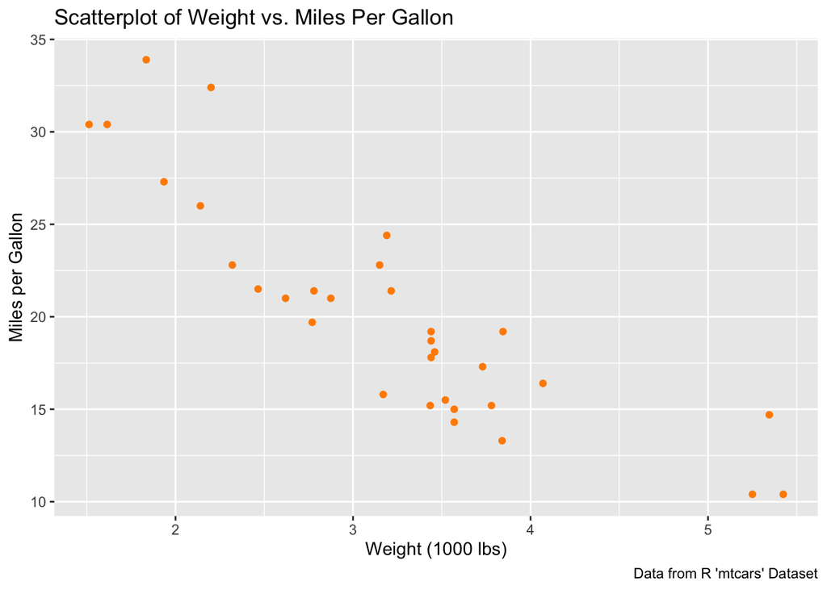

```r
ggplot(data = mtcars, mapping = aes(x = wt, y = mpg)) +
  geom_point(color = "darkorange") +
  labs(title = "Scatterplot of Weight vs. Miles Per Gallon", x = "Weight (1000 lbs)", y = "Miles per Gallon", caption = "Data from R 'mtcars' Dataset")
```

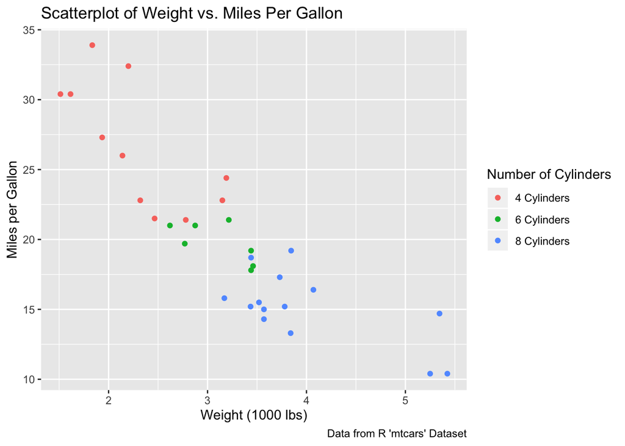

```r
ggplot(data = mtcars, mapping = aes(x = wt, y = mpg)) +
  geom_point(mapping = aes(color = cyl)) +
  labs(title = "Scatterplot of Weight vs. Miles Per Gallon", x = "Weight (1000 lbs)", y = "Miles per Gallon", caption = "Data from R 'mtcars' Dataset", color = "Number of Cylinders")
```

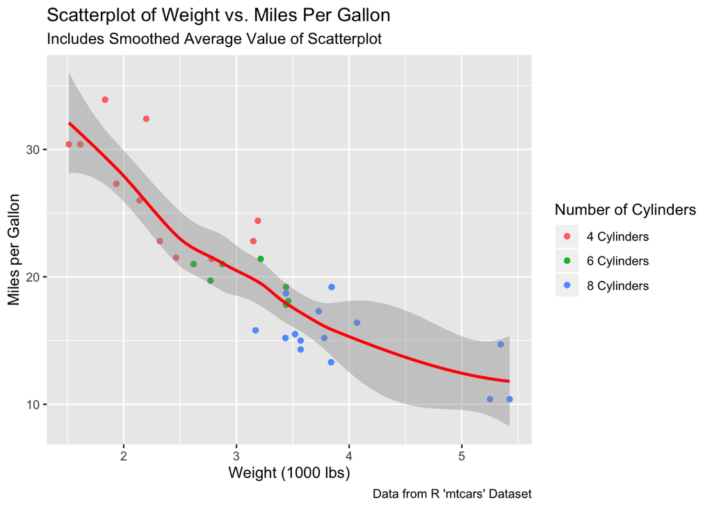

```r
ggplot(data = mtcars, mapping = aes(x = wt, y = mpg)) +
  geom_point(mapping = aes(color = cyl)) +
  geom_smooth(color = "red") +
  labs(title = "Scatterplot of Weight vs. Miles Per Gallon", subtitle = "Includes Smoothed Average Value of Scatterplot", x = "Weight (1000 lbs)", y = "Miles per Gallon", caption = "Data from R 'mtcars' Dataset", color = "Number of Cylinders")
## `geom_smooth()` using method = 'loess' and formula 'y ~ x'
```

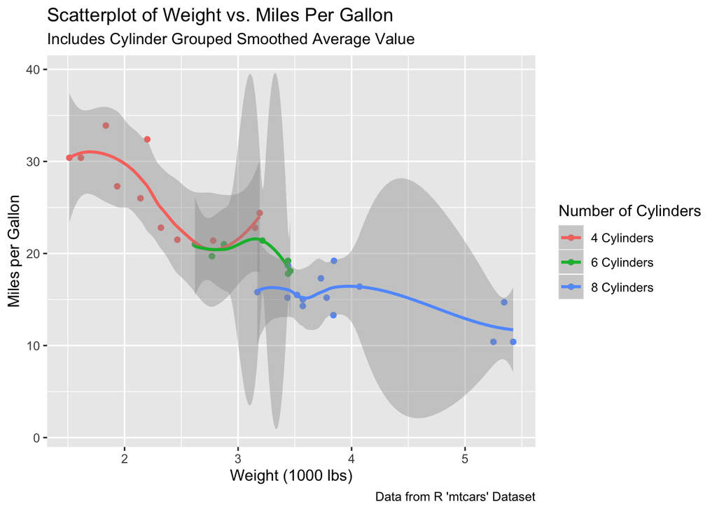

```r
ggplot(data = mtcars, mapping = aes(x = wt, y = mpg)) +
  geom_point(mapping = aes(color = cyl)) +
  geom_smooth(mapping = aes(color = cyl)) +
  labs(title = "Scatterplot of Weight vs. Miles Per Gallon", subtitle = "Includes Cylinder Grouped Smoothed Average Value", x = "Weight (1000 lbs)", y = "Miles per Gallon", caption = "Data from R 'mtcars' Dataset", color = "Number of Cylinders")
## `geom_smooth()` using method = 'loess' and formula 'y ~ x'
```

#### Assignment 2

2. Create barplots to show the counts and proportion of cars according to
   1. distinct categories of transmission.
   2. distinct categories of transmission and the number of cylinders.

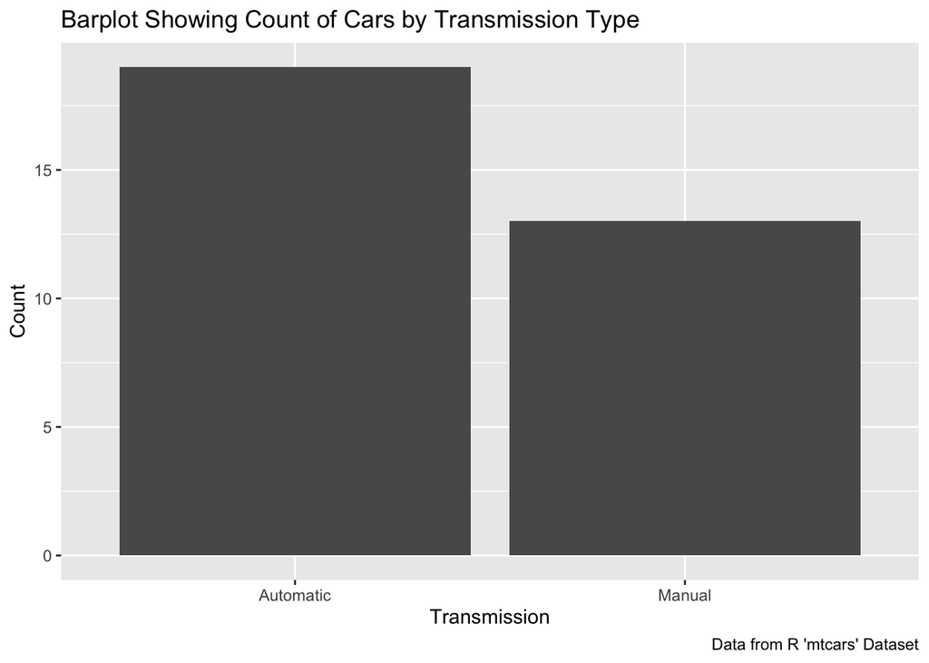

```r
ggplot(data = mtcars) +
  geom_bar(mapping = aes(x = am)) +
  labs(title = "Barplot Showing Count of Cars by Transmission Type", x = "Transmission", y = "Count", caption = "Data from R 'mtcars' Dataset")
```

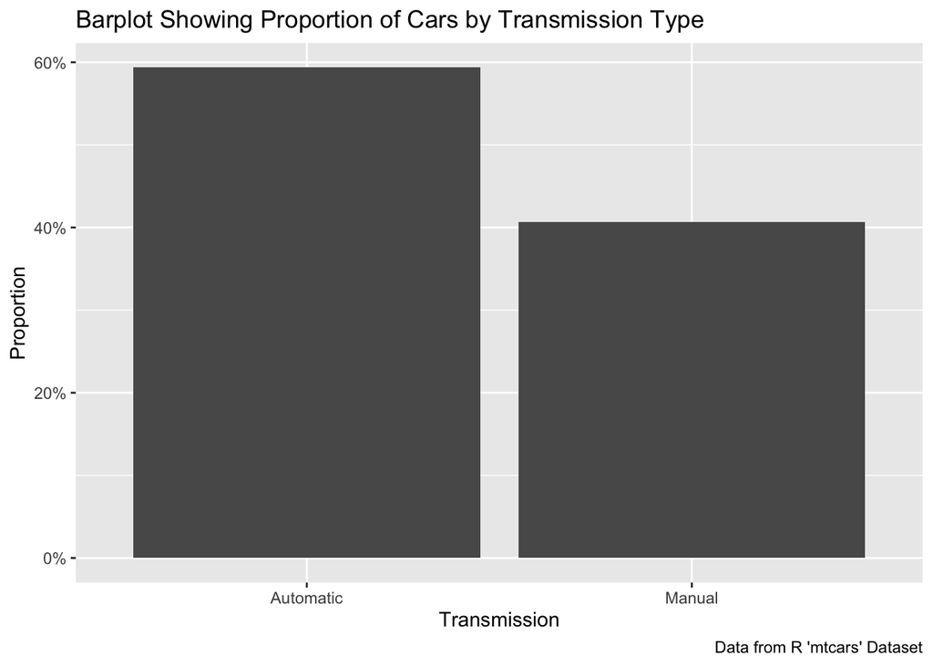

```r
ggplot(data = mtcars) +
  geom_bar(mapping = aes(x = am, y = stat(prop), group = 1)) +
  scale_y_continuous(labels=scales::percent) +
  labs(title = "Barplot Showing Proportion of Cars by Transmission Type", x = "Transmission", y = "Proportion", caption = "Data from R 'mtcars' Dataset")
```

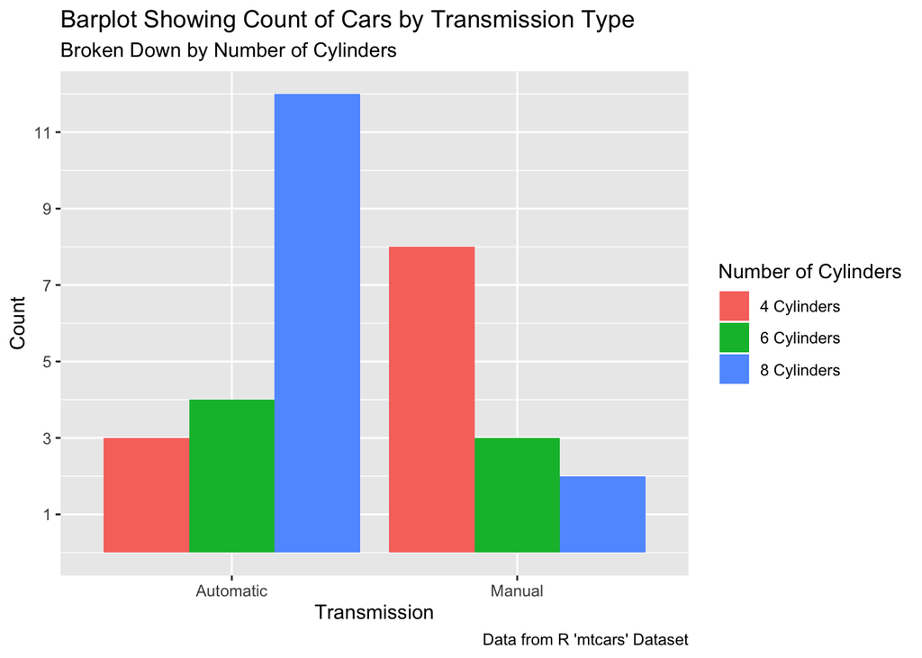

```r
ggplot(data = mtcars) +
  geom_bar(mapping = aes(x = am, fill = cyl), position = "dodge") +
  labs(title = "Barplot Showing Count of Cars by Transmission Type", subtitle = "Broken Down by Number of Cylinders", x = "Transmission", y = "Count", caption = "Data from R 'mtcars' Dataset", fill = "Number of Cylinders") +
  scale_y_continuous(breaks = c(1, 3, 5, 7, 9, 11, 13))
```

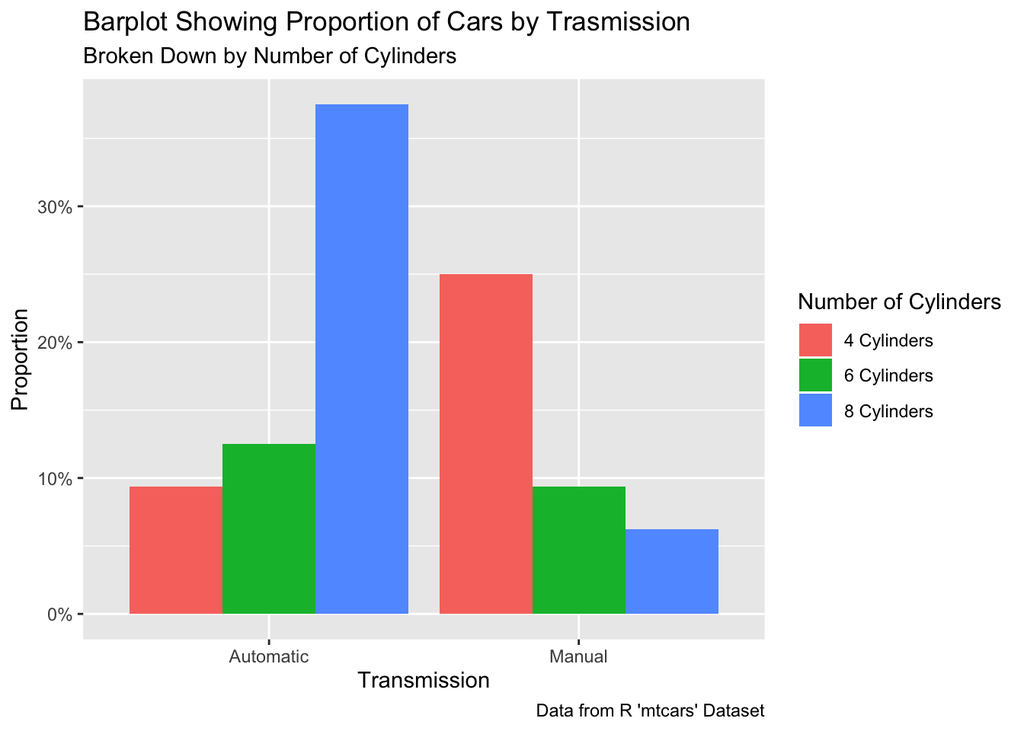

```r
ggplot(data = mtcars) +
  geom_bar(mapping = aes(x = am, y = (..count..)/sum(..count..), fill = cyl), position = "dodge") +
  scale_y_continuous(labels=scales::percent) +
  labs(title = "Barplot Showing Proportion of Cars by Trasmission", subtitle = "Broken Down by Number of Cylinders", x = "Transmission", y = "Proportion", caption = "Data from R 'mtcars' Dataset", fill = "Number of Cylinders")
```

#### Assignment 3

3. Using your knowledge on facets, create a scatter plot showing the relationship between weight of cars and miles per gallon and subset it according to the levels of cylinders.
   1. Now modify the above plot and subset the plot with your knowledge on facets, across levels of cylinders and gears.

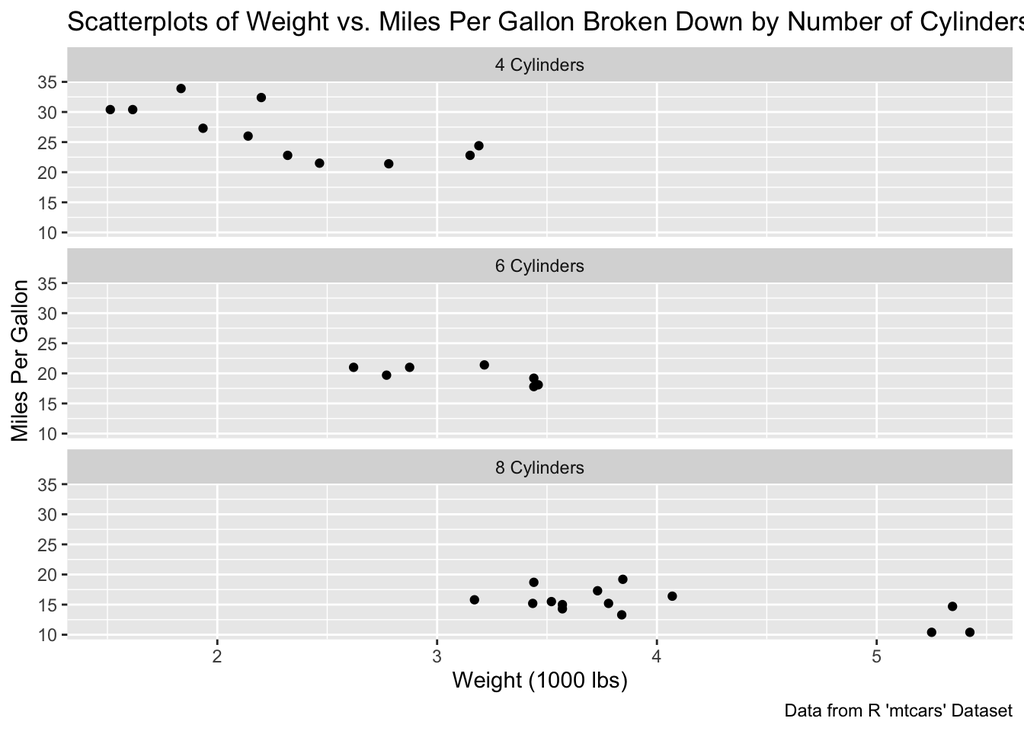

```r
ggplot(data = mtcars, mapping = aes(x = wt, y = mpg)) +
  geom_point() +
  facet_wrap(~cyl, nrow = 3) +
  labs(title = "Scatterplots of Weight vs. Miles Per Gallon Broken Down by Number of Cylinders", x = "Weight (1000 lbs)", y = "Miles Per Gallon", caption = "Data from R 'mtcars' Dataset")
```

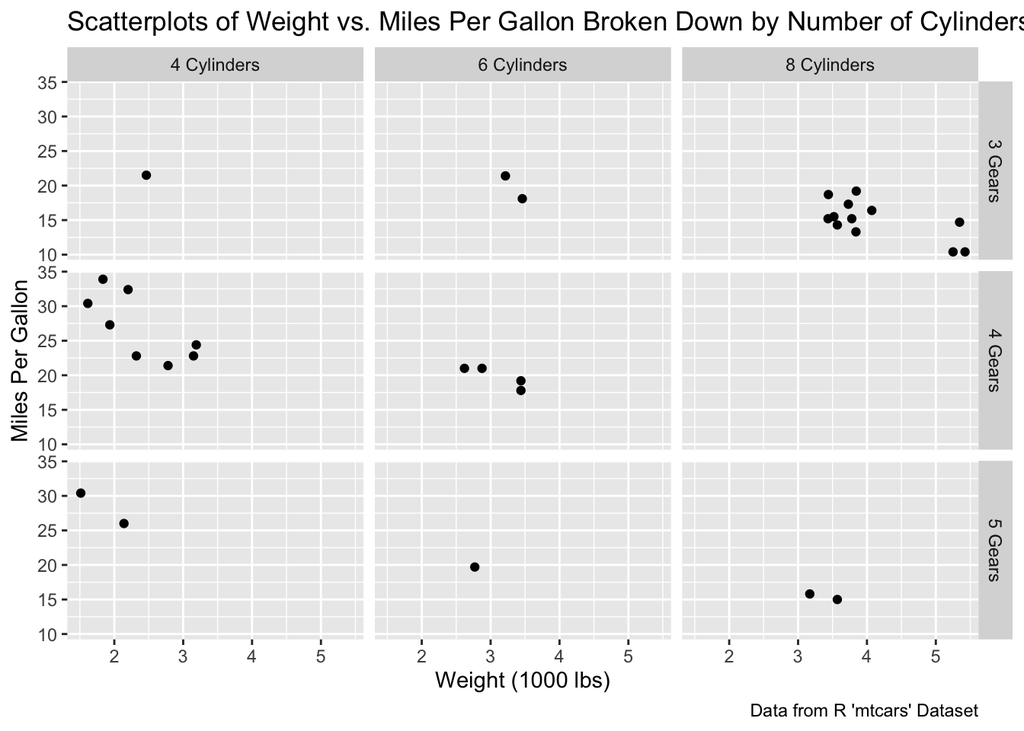

```r
ggplot(data = mtcars, mapping = aes(x = wt, y = mpg)) +
  geom_point() +
  facet_grid(gear~cyl) +
  labs(title = "Scatterplots of Weight vs. Miles Per Gallon Broken Down by Number of Cylinders and Number of Gears", x = "Weight (1000 lbs)", y = "Miles Per Gallon", caption = "Data from R 'mtcars' Dataset")
```